# Assignment 7: Preprocessing

Ral Mogbogu

2026-01-07

```r
library(ggplot2)
library(dplyr)
library(caret)
library(corrplot)
library(tidyr)
library(reshape2)
library(mice)
library(magrittr)
getwd()
```

```
## [1] "C:/Users/somto/OneDrive/Documents/ANLY530ML"
```

```r
library(readr)
df <- read_csv("bank_data.csv")
```

```
## ──────────────────────────────────────────────────────── Delimiter: "," dbl
## (12): ...1, SeriousDlqin2yrs, RevolvingUtilizationOfUnsecuredLines, age,...
```

```r
str(df)
```

```
## spc_tbl_ [150,000 × 12] (S3: spec_tbl_df/tbl_df/tbl/data.frame)
##  $ ...1                                : num [1:150000] 1 2 3 4 5 6 7 8 9 10 ...
##  $ SeriousDlqin2yrs                    : num [1:150000] 1 0 0 0 0 0 0 0 0 0 ...
##  $ RevolvingUtilizationOfUnsecuredLines: num [1:150000] 0.766 0.957 0.658 0.234 0.907 ...
##  $ age                                 : num [1:150000] 45 40 38 30 49 74 57 39 27 57 ...
##  $ NumberOfTime30-59DaysPastDueNotWorse: num [1:150000] 2 0 1 0 1 0 0 0 0 0 ...
##  $ DebtRatio                           : num [1:150000] 0.803 0.1219 0.0851 0.036 0.0249 ...
##  $ MonthlyIncome                       : num [1:150000] 9120 2600 3042 3300 63588 ...
##  $ NumberOfOpenCreditLinesAndLoans     : num [1:150000] 13 4 2 5 7 3 8 8 2 9 ...
##  $ NumberOfTimes90DaysLate             : num [1:150000] 0 0 1 0 0 0 0 0 0 0 ...
##  $ NumberRealEstateLoansOrLines        : num [1:150000] 6 0 0 0 1 1 3 0 0 4 ...
##  $ NumberOfTime60-89DaysPastDueNotWorse: num [1:150000] 0 0 0 0 0 0 0 0 0 0 ...
##  $ NumberOfDependents                  : num [1:150000] 2 1 0 0 0 1 0 0 NA 2 ...
##  - attr(*, "spec")=
##   .. cols(
##   ..   ...1 = col_double(),
##   ..   SeriousDlqin2yrs = col_double(),
##   ..   RevolvingUtilizationOfUnsecuredLines = col_double(),
##   ..   age = col_double(),
##   ..   `NumberOfTime30-59DaysPastDueNotWorse` = col_double(),
##   ..   DebtRatio = col_double(),
##   ..   MonthlyIncome = col_double(),
##   ..   NumberOfOpenCreditLinesAndLoans = col_double(),
##   ..   NumberOfTimes90DaysLate = col_double(),
##   ..   NumberRealEstateLoansOrLines = col_double(),
##   ..   `NumberOfTime60-89DaysPastDueNotWorse` = col_double(),
##   ..   NumberOfDependents = col_double()
##   .. )
##  - attr(*, "problems")=<externalptr>
```

```r
library(skimr)
skim(df)
```

Data summary

| Name | df |
| --- | --- |
| Number of rows | 150000 |
| Number of columns | 12 |
| _______________________ |  |
| Column type frequency: |  |
| numeric | 12 |
| ________________________ |  |
| Group variables | None |

**Variable type: numeric**

| skim_variable | n_missing | complete_rate | mean | sd | p0 | p25 | p50 | p75 | p100 | hist |
| --- | --- | --- | --- | --- | --- | --- | --- | --- | --- | --- |
| …1 | 0 | 1.00 | 75000.50 | 43301.41 | 1 | 37500.75 | 75000.50 | 112500.25 | 150000 | ▇▇▇▇▇ |
| SeriousDlqin2yrs | 0 | 1.00 | 0.07 | 0.25 | 0 | 0.00 | 0.00 | 0.00 | 1 | ▇▁▁▁▁ |
| RevolvingUtilizationOfUnsecuredLines | 0 | 1.00 | 6.05 | 249.76 | 0 | 0.03 | 0.15 | 0.56 | 50708 | ▇▁▁▁▁ |
| age | 0 | 1.00 | 52.30 | 14.77 | 0 | 41.00 | 52.00 | 63.00 | 109 | ▁▅▇▃▁ |
| NumberOfTime30-59DaysPastDueNotWorse | 0 | 1.00 | 0.42 | 4.19 | 0 | 0.00 | 0.00 | 0.00 | 98 | ▇▁▁▁▁ |
| DebtRatio | 0 | 1.00 | 353.01 | 2037.82 | 0 | 0.18 | 0.37 | 0.87 | 329664 | ▇▁▁▁▁ |
| MonthlyIncome | 29731 | 0.80 | 6670.22 | 14384.67 | 0 | 3400.00 | 5400.00 | 8249.00 | 3008750 | ▇▁▁▁▁ |
| NumberOfOpenCreditLinesAndLoans | 0 | 1.00 | 8.45 | 5.15 | 0 | 5.00 | 8.00 | 11.00 | 58 | ▇▂▁▁▁ |
| NumberOfTimes90DaysLate | 0 | 1.00 | 0.27 | 4.17 | 0 | 0.00 | 0.00 | 0.00 | 98 | ▇▁▁▁▁ |
| NumberRealEstateLoansOrLines | 0 | 1.00 | 1.02 | 1.13 | 0 | 0.00 | 1.00 | 2.00 | 54 | ▇▁▁▁▁ |
| NumberOfTime60-89DaysPastDueNotWorse | 0 | 1.00 | 0.24 | 4.16 | 0 | 0.00 | 0.00 | 0.00 | 98 | ▇▁▁▁▁ |
| NumberOfDependents | 3924 | 0.97 | 0.76 | 1.12 | 0 | 0.00 | 0.00 | 1.00 | 20 | ▇▁▁▁▁ |

```r
View(df)
```

# Outline

- Start with handling all the missing or NA values in the dataset. It is up to you to do whatever you want with the bad values
- Find the outliers in at least two columns and handle them
- Normalize the values of two columns
- Create the correlation matrix between the variables
- What are the three most important features?

## Preprocess the data –> Missing data | Outliers | Normalization

## Feature Selection –> Correlation matrix | Feature Importance

```r
summary(df)
```

```
##       ...1        SeriousDlqin2yrs  RevolvingUtilizationOfUnsecuredLines
##  Min.   :     1   Min.   :0.00000   Min.   :    0.00
##  1st Qu.: 37501   1st Qu.:0.00000   1st Qu.:    0.03
##  Median : 75001   Median :0.00000   Median :    0.15
##  Mean   : 75001   Mean   :0.06684   Mean   :    6.05
##  3rd Qu.:112500   3rd Qu.:0.00000   3rd Qu.:    0.56
##  Max.   :150000   Max.   :1.00000   Max.   :50708.00
##
##       age        NumberOfTime30-59DaysPastDueNotWorse   DebtRatio
##  Min.   :  0.0   Min.   : 0.000                       Min.   :     0.0
##  1st Qu.: 41.0   1st Qu.: 0.000                       1st Qu.:     0.2
##  Median : 52.0   Median : 0.000                       Median :     0.4
##  Mean   : 52.3   Mean   : 0.421                       Mean   :   353.0
##  3rd Qu.: 63.0   3rd Qu.: 0.000                       3rd Qu.:     0.9
##  Max.   :109.0   Max.   :98.000                       Max.   :329664.0
##
##  MonthlyIncome     NumberOfOpenCreditLinesAndLoans NumberOfTimes90DaysLate
##  Min.   :      0   Min.   : 0.000                  Min.   : 0.000
##  1st Qu.:   3400   1st Qu.: 5.000                  1st Qu.: 0.000
##  Median :   5400   Median : 8.000                  Median : 0.000
##  Mean   :   6670   Mean   : 8.453                  Mean   : 0.266
##  3rd Qu.:   8249   3rd Qu.:11.000                  3rd Qu.: 0.000
##  Max.   :3008750   Max.   :58.000                  Max.   :98.000
##  NA's   :29731
##  NumberRealEstateLoansOrLines NumberOfTime60-89DaysPastDueNotWorse
##  Min.   : 0.000               Min.   : 0.0000
##  1st Qu.: 0.000               1st Qu.: 0.0000
##  Median : 1.000               Median : 0.0000
##  Mean   : 1.018               Mean   : 0.2404
##  3rd Qu.: 2.000               3rd Qu.: 0.0000
##  Max.   :54.000               Max.   :98.0000
##
##  NumberOfDependents
##  Min.   : 0.000
##  1st Qu.: 0.000
##  Median : 0.000
##  Mean   : 0.757
##  3rd Qu.: 1.000
##  Max.   :20.000
##  NA's   :3924
```

```r
head(df)
```

```
## # A tibble: 6 × 12
##    ...1 SeriousDlqin2yrs RevolvingUtilizationOfUn…¹   age NumberOfTime30-59Day…²
##   <dbl>            <dbl>                      <dbl> <dbl>                  <dbl>
## 1     1                1                      0.766    45                      2
## 2     2                0                      0.957    40                      0
## 3     3                0                      0.658    38                      1
## 4     4                0                      0.234    30                      0
## 5     5                0                      0.907    49                      1
## 6     6                0                      0.213    74                      0
## # ℹ abbreviated names: ¹RevolvingUtilizationOfUnsecuredLines,
## #   ²`NumberOfTime30-59DaysPastDueNotWorse`
## # ℹ 7 more variables: DebtRatio <dbl>, MonthlyIncome <dbl>,
## #   NumberOfOpenCreditLinesAndLoans <dbl>, NumberOfTimes90DaysLate <dbl>,
## #   NumberRealEstateLoansOrLines <dbl>,
## #   `NumberOfTime60-89DaysPastDueNotWorse` <dbl>, NumberOfDependents <dbl>
```

```r
bankdf <- df #copydf
```

```r
colSums(is.na(df))
```

```
##                                 ...1                     SeriousDlqin2yrs
##                                    0                                    0
## RevolvingUtilizationOfUnsecuredLines                                  age
##                                    0                                    0
## NumberOfTime30-59DaysPastDueNotWorse                            DebtRatio
##                                    0                                    0
##                        MonthlyIncome      NumberOfOpenCreditLinesAndLoans
##                                29731                                    0
##              NumberOfTimes90DaysLate         NumberRealEstateLoansOrLines
##                                    0                                    0
## NumberOfTime60-89DaysPastDueNotWorse                   NumberOfDependents
##                                    0                                 3924
```

```r
#large proportion of data missing from MonthlyIncome and NoOfDependents
#omit and keep only complete cases
#downside is the loss of data and reduction in sample size/power which may bring about biased results
#using MICE, mean or median method is better in my experience
```

```r
bankdf <- df[complete.cases(df), ] #removes NA and leaves only complete cases
str(bankdf)
```

```
## tibble [120,269 × 12] (S3: tbl_df/tbl/data.frame)
##  $ ...1                                : num [1:120269] 1 2 3 4 5 6 8 10 11 12 ...
##  $ SeriousDlqin2yrs                    : num [1:120269] 1 0 0 0 0 0 0 0 0 0 ...
##  $ RevolvingUtilizationOfUnsecuredLines: num [1:120269] 0.766 0.957 0.658 0.234 0.907 ...
##  $ age                                 : num [1:120269] 45 40 38 30 49 74 39 57 30 51 ...
##  $ NumberOfTime30-59DaysPastDueNotWorse: num [1:120269] 2 0 1 0 1 0 0 0 0 0 ...
##  $ DebtRatio                           : num [1:120269] 0.803 0.1219 0.0851 0.036 0.0249 ...
##  $ MonthlyIncome                       : num [1:120269] 9120 2600 3042 3300 63588 ...
##  $ NumberOfOpenCreditLinesAndLoans     : num [1:120269] 13 4 2 5 7 3 8 9 5 7 ...
##  $ NumberOfTimes90DaysLate             : num [1:120269] 0 0 1 0 0 0 0 0 0 0 ...
##  $ NumberRealEstateLoansOrLines        : num [1:120269] 6 0 0 0 1 1 0 4 0 2 ...
##  $ NumberOfTime60-89DaysPastDueNotWorse: num [1:120269] 0 0 0 0 0 0 0 0 0 0 ...
##  $ NumberOfDependents                  : num [1:120269] 2 1 0 0 0 1 0 2 0 2 ...
```

```r
skim(bankdf)
```

Data summary

| Name | bankdf |
| --- | --- |
| Number of rows | 120269 |
| Number of columns | 12 |
| _______________________ |  |
| Column type frequency: |  |
| numeric | 12 |
| ________________________ |  |
| Group variables | None |

**Variable type: numeric**

| skim_variable | n_missing | complete_rate | mean | sd | p0 | p25 | p50 | p75 | p100 | hist |
| --- | --- | --- | --- | --- | --- | --- | --- | --- | --- | --- |
| …1 | 0 | 1 | 75026.01 | 43286.03 | 1 | 37678.00 | 74969.00 | 112494.00 | 150000.0 | ▇▇▇▇▇ |
| SeriousDlqin2yrs | 0 | 1 | 0.07 | 0.25 | 0 | 0.00 | 0.00 | 0.00 | 1.0 | ▇▁▁▁▁ |
| RevolvingUtilizationOfUnsecuredLines | 0 | 1 | 5.90 | 257.04 | 0 | 0.04 | 0.18 | 0.58 | 50708.0 | ▇▁▁▁▁ |
| age | 0 | 1 | 51.29 | 14.43 | 0 | 40.00 | 51.00 | 61.00 | 103.0 | ▁▅▇▃▁ |
| NumberOfTime30-59DaysPastDueNotWorse | 0 | 1 | 0.38 | 3.50 | 0 | 0.00 | 0.00 | 0.00 | 98.0 | ▇▁▁▁▁ |
| DebtRatio | 0 | 1 | 26.60 | 424.45 | 0 | 0.14 | 0.30 | 0.48 | 61106.5 | ▇▁▁▁▁ |
| MonthlyIncome | 0 | 1 | 6670.22 | 14384.67 | 0 | 3400.00 | 5400.00 | 8249.00 | 3008750.0 | ▇▁▁▁▁ |
| NumberOfOpenCreditLinesAndLoans | 0 | 1 | 8.76 | 5.17 | 0 | 5.00 | 8.00 | 11.00 | 58.0 | ▇▂▁▁▁ |
| NumberOfTimes90DaysLate | 0 | 1 | 0.21 | 3.47 | 0 | 0.00 | 0.00 | 0.00 | 98.0 | ▇▁▁▁▁ |
| NumberRealEstateLoansOrLines | 0 | 1 | 1.05 | 1.15 | 0 | 0.00 | 1.00 | 2.00 | 54.0 | ▇▁▁▁▁ |
| NumberOfTime60-89DaysPastDueNotWorse | 0 | 1 | 0.19 | 3.45 | 0 | 0.00 | 0.00 | 0.00 | 98.0 | ▇▁▁▁▁ |
| NumberOfDependents | 0 | 1 | 0.85 | 1.15 | 0 | 0.00 | 0.00 | 2.00 | 20.0 | ▇▁▁▁▁ |

```r
#compare the sample sizes before and after omitting
nrow(df)
```

```
## [1] 150000
```

```r
nrow(bankdf)
```

```
## [1] 120269
```

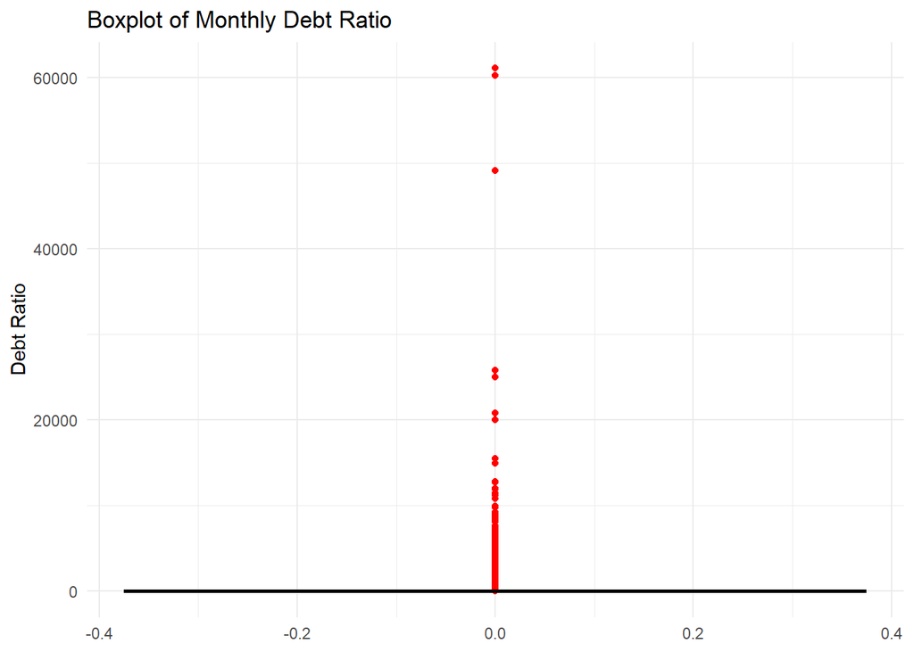

```r
# using DebtRatio & RevolvingUtilizationOfUnsecuredLines because they have some of the highest "max" values (329664.0 & 50708.00); so they may be outliers present in variables

library(ggplot2)

ggplot(bankdf, aes(y = DebtRatio)) +
  geom_boxplot(fill = "lightblue", color = "black", outlier.colour = "red", outlier.shape = 16) +
  labs(title = "Boxplot of Monthly Debt Ratio",
       y = "Debt Ratio") +
  theme_minimal()
```

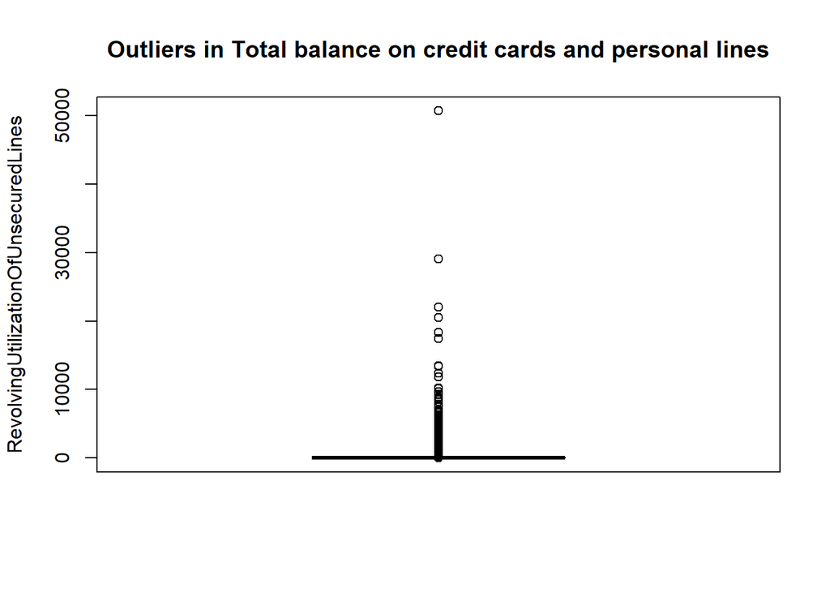

```r
boxplot(bankdf$RevolvingUtilizationOfUnsecuredLines, main = "Outliers in Total balance on credit cards and personal lines", ylab = "RevolvingUtilizationOfUnsecuredLines")
```

```r
#remove debtratio
iqr <- IQR(bankdf$DebtRatio)
up_quantrange <- quantile (bankdf$DebtRatio, 0.75) + 1.5*iqr
low_quantrange <- quantile (bankdf$DebtRatio, 0.25) - 1.5*iqr

iqr
```

```
## [1] 0.3391718
```

```r
up_quantrange
```

```
##       75%
## 0.9913172
```

```r
low_quantrange
```

```
##        25%
## -0.3653701
```

```r
remove <- subset(bankdf, DebtRatio > low_quantrange & bankdf$DebtRatio < up_quantrange)
remove
```

```
## # A tibble: 112,911 × 12
##     ...1 SeriousDlqin2yrs RevolvingUtilizationOfU…¹   age NumberOfTime30-59Day…²
##    <dbl>            <dbl>                     <dbl> <dbl>                  <dbl>
##  1     1                1                    0.766     45                      2
##  2     2                0                    0.957     40                      0
##  3     3                0                    0.658     38                      1
##  4     4                0                    0.234     30                      0
##  5     5                0                    0.907     49                      1
##  6     6                0                    0.213     74                      0
##  7     8                0                    0.754     39                      0
##  8    10                0                    0.189     57                      0
##  9    11                0                    0.644     30                      0
## 10    12                0                    0.0188    51                      0
## # ℹ 112,901 more rows
## # ℹ abbreviated names: ¹RevolvingUtilizationOfUnsecuredLines,
## #   ²`NumberOfTime30-59DaysPastDueNotWorse`
## # ℹ 7 more variables: DebtRatio <dbl>, MonthlyIncome <dbl>,
## #   NumberOfOpenCreditLinesAndLoans <dbl>, NumberOfTimes90DaysLate <dbl>,
## #   NumberRealEstateLoansOrLines <dbl>,
## #   `NumberOfTime60-89DaysPastDueNotWorse` <dbl>, NumberOfDependents <dbl>
```

```r
# remove RevolvingUtilizationOfUnsecuredLines & finalize
iqr1 <- IQR(bankdf$RevolvingUtilizationOfUnsecuredLines)
up_quantrange1 <- quantile (bankdf$RevolvingUtilizationOfUnsecuredLines, 0.75) + 1.5*iqr1
low_quantrange1 <- quantile (bankdf$RevolvingUtilizationOfUnsecuredLines, 0.25) - 1.5*iqr1

iqr1
```

```
## [1] 0.5443439
```

```r
up_quantrange1
```

```
##      75%
## 1.395944
```

```r
low_quantrange1
```

```
##        25%
## -0.7814318
```

```r
remove1 <- subset(remove, RevolvingUtilizationOfUnsecuredLines > low_quantrange1 & RevolvingUtilizationOfUnsecuredLines < up_quantrange1)
remove1
```

```
## # A tibble: 112,400 × 12
##     ...1 SeriousDlqin2yrs RevolvingUtilizationOfU…¹   age NumberOfTime30-59Day…²
##    <dbl>            <dbl>                     <dbl> <dbl>                  <dbl>
##  1     1                1                    0.766     45                      2
##  2     2                0                    0.957     40                      0
##  3     3                0                    0.658     38                      1
##  4     4                0                    0.234     30                      0
##  5     5                0                    0.907     49                      1
##  6     6                0                    0.213     74                      0
##  7     8                0                    0.754     39                      0
##  8    10                0                    0.189     57                      0
##  9    11                0                    0.644     30                      0
## 10    12                0                    0.0188    51                      0
## # ℹ 112,390 more rows
## # ℹ abbreviated names: ¹RevolvingUtilizationOfUnsecuredLines,
## #   ²`NumberOfTime30-59DaysPastDueNotWorse`
## # ℹ 7 more variables: DebtRatio <dbl>, MonthlyIncome <dbl>,
## #   NumberOfOpenCreditLinesAndLoans <dbl>, NumberOfTimes90DaysLate <dbl>,
## #   NumberRealEstateLoansOrLines <dbl>,
## #   `NumberOfTime60-89DaysPastDueNotWorse` <dbl>, NumberOfDependents <dbl>
```

```r
# outliers check: original vs removed DebtRatio
summary(bankdf$DebtRatio)
```

```
##     Min.  1st Qu.   Median     Mean  3rd Qu.     Max.
##     0.00     0.14     0.30    26.60     0.48 61106.50
```

```r
summary(remove1$DebtRatio)
```

```
##    Min. 1st Qu.  Median    Mean 3rd Qu.    Max.
##  0.0000  0.1330  0.2780  0.3055  0.4394  0.9913
```

```r
# outliers check: original vs removed RevolvingUtilizationOfUnsecuredLines
summary(bankdf$RevolvingUtilizationOfUnsecuredLines)
```

```
##     Min.  1st Qu.   Median     Mean  3rd Qu.     Max.
##     0.00     0.04     0.18     5.90     0.58 50708.00
```

```r
summary(remove1$RevolvingUtilizationOfUnsecuredLines)
```

```
##    Min. 1st Qu.  Median    Mean 3rd Qu.    Max.
## 0.00000 0.03398 0.17047 0.32539 0.56296 1.39535
```

### with the removal of missing values and outliers, the worry of losing data is valid due to how much the descriptive statistics of Debt-Ratio and Revolving Utilization Of Unsecured Lines has changed.

```r
preProClean <- preProcess(x = remove1, method = c("scale", "center"))
banknormal <- predict(preProClean, remove1 %>% na.omit)
print(str(banknormal))
```

```
## tibble [112,400 × 12] (S3: tbl_df/tbl/data.frame)
##  $ ...1                                : num [1:112400] -1.73 -1.73 -1.73 -1.73 -1.73 ...
##  $ SeriousDlqin2yrs                    : num [1:112400] 3.75 -0.267 -0.267 -0.267 -0.267 ...
##  $ RevolvingUtilizationOfUnsecuredLines: num [1:112400] 1.267 1.817 0.957 -0.263 1.673 ...
##  $ age                                 : num [1:112400] -0.441 -0.786 -0.924 -1.477 -0.164 ...
##  $ NumberOfTime30-59DaysPastDueNotWorse: num [1:112400] 0.448 -0.106 0.171 -0.106 0.171 ...
##  $ DebtRatio                           : num [1:112400] 2.24 -0.826 -0.992 -1.213 -1.263 ...
##  $ MonthlyIncome                       : num [1:112400] 0.146 -0.294 -0.264 -0.247 3.824 ...
##  $ NumberOfOpenCreditLinesAndLoans     : num [1:112400] 0.843 -0.913 -1.303 -0.718 -0.327 ...
##  $ NumberOfTimes90DaysLate             : num [1:112400] -0.0605 -0.0605 0.2188 -0.0605 -0.0605 ...
##  $ NumberRealEstateLoansOrLines        : num [1:112400] 4.617 -0.94 -0.94 -0.94 -0.014 ...
##  $ NumberOfTime60-89DaysPastDueNotWorse: num [1:112400] -0.0543 -0.0543 -0.0543 -0.0543 -0.0543 ...
##  $ NumberOfDependents                  : num [1:112400] 0.998 0.127 -0.744 -0.744 -0.744 ...
## NULL
```

```r
summary(banknormal$DebtRatio)
```

```
##    Min. 1st Qu.  Median    Mean 3rd Qu.    Max.
## -1.3750 -0.7763 -0.1234  0.0000  0.6030  3.0872
```

```r
summary(banknormal$RevolvingUtilizationOfUnsecuredLines)
```

```
##    Min. 1st Qu.  Median    Mean 3rd Qu.    Max.
## -0.9357 -0.8380 -0.4455  0.0000  0.6832  3.0768
```

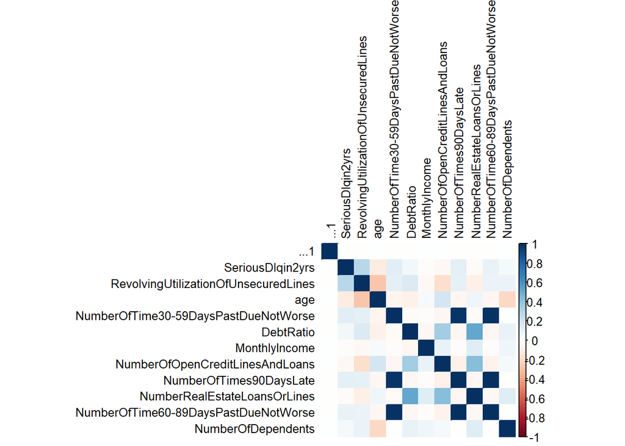

```r
bank_corrmat <- cor(remove1, use="pairwise.complete.obs")
corrplot(bank_corrmat, method="color", tl.col="black", tl.cex=0.8)
```

```r
print(bank_corrmat)
```

```
##                                               ...1 SeriousDlqin2yrs
## ...1                                  1.0000000000      0.004456452
## SeriousDlqin2yrs                      0.0044564517      1.000000000
## RevolvingUtilizationOfUnsecuredLines -0.0043895076      0.272104719
## age                                   0.0041323471     -0.106057096
## NumberOfTime30-59DaysPastDueNotWorse -0.0020753281      0.123590196
## DebtRatio                            -0.0006173722      0.057452089
## MonthlyIncome                         0.0026808281     -0.019736865
## NumberOfOpenCreditLinesAndLoans       0.0025409381     -0.037537514
## NumberOfTimes90DaysLate              -0.0028003880      0.112932878
## NumberRealEstateLoansOrLines         -0.0010328537     -0.023978848
## NumberOfTime60-89DaysPastDueNotWorse -0.0022214930      0.096110617
## NumberOfDependents                    0.0013786979      0.047295716
##                                      RevolvingUtilizationOfUnsecuredLines
## ...1                                                         -0.004389508
## SeriousDlqin2yrs                                              0.272104719
## RevolvingUtilizationOfUnsecuredLines                          1.000000000
## age                                                          -0.272488759
## NumberOfTime30-59DaysPastDueNotWorse                          0.116308275
## DebtRatio                                                     0.151951277
## MonthlyIncome                                                -0.036017346
## NumberOfOpenCreditLinesAndLoans                              -0.174899578
## NumberOfTimes90DaysLate                                       0.101109622
## NumberRealEstateLoansOrLines                                 -0.087216705
## NumberOfTime60-89DaysPastDueNotWorse                          0.087740726
## NumberOfDependents                                            0.085415960
##                                               age
## ...1                                  0.004132347
## SeriousDlqin2yrs                     -0.106057096
## RevolvingUtilizationOfUnsecuredLines -0.272488759
## age                                   1.000000000
## NumberOfTime30-59DaysPastDueNotWorse -0.050674131
## DebtRatio                            -0.072923851
## MonthlyIncome                         0.036427599
## NumberOfOpenCreditLinesAndLoans       0.185399476
## NumberOfTimes90DaysLate              -0.048854151
## NumberRealEstateLoansOrLines          0.066941140
## NumberOfTime60-89DaysPastDueNotWorse -0.044755924
## NumberOfDependents                   -0.205465437
##                                      NumberOfTime30-59DaysPastDueNotWorse
```

[output cut: 75 more lines]

```
## NumberOfTime60-89DaysPastDueNotWorse                          1.000000000
## NumberOfDependents                                           -0.005699043
##                                      NumberOfDependents
## ...1                                        0.001378698
## SeriousDlqin2yrs                            0.047295716
## RevolvingUtilizationOfUnsecuredLines        0.085415960
## age                                        -0.205465437
## NumberOfTime30-59DaysPastDueNotWorse        0.002603343
## DebtRatio                                   0.097645005
## MonthlyIncome                               0.063441725
## NumberOfOpenCreditLinesAndLoans             0.041502421
## NumberOfTimes90DaysLate                    -0.004470531
## NumberRealEstateLoansOrLines                0.130070708
## NumberOfTime60-89DaysPastDueNotWorse       -0.005699043
## NumberOfDependents                          1.000000000
```

# Correlation plot and matrix show squares leaning towards dark blue as having strong correlation.

```r
banknormal$SeriousDlqin2yrs <- as.factor(banknormal$SeriousDlqin2yrs)
```

```r
set.seed(7)

bank_index <- createDataPartition(banknormal$SeriousDlqin2yrs, p = 0.8, list = FALSE)
train <- banknormal[bank_index, ]
test <- banknormal[-bank_index, ]
```

```r
library(randomForest)
# error in "NumberOfTime30-59DaysPastDueNotWorse" as R could not locate the vaiable; I assume due to the hyphen or something else; so

colnames(train) <- make.names(colnames(train))
colnames(test) <- make.names(colnames(test))


train <- na.omit(train)


library(randomForest)
set.seed(7)

fit.rf <- randomForest(SeriousDlqin2yrs~., data = train, ntree = 50, importance = TRUE)
```

```r
varImp(fit.rf)
```

```
##                                      -0.266680012492836 3.7497789723919
## ...1                                         -0.7139973      -0.7139973
## RevolvingUtilizationOfUnsecuredLines         17.6837374      17.6837374
## age                                           8.0901647       8.0901647
## NumberOfTime30.59DaysPastDueNotWorse         18.1484181      18.1484181
## DebtRatio                                    10.9759763      10.9759763
## MonthlyIncome                                11.3942258      11.3942258
## NumberOfOpenCreditLinesAndLoans               8.1491510       8.1491510
## NumberOfTimes90DaysLate                      30.3472935      30.3472935
## NumberRealEstateLoansOrLines                  2.6683061       2.6683061
## NumberOfTime60.89DaysPastDueNotWorse         18.5769015      18.5769015
## NumberOfDependents                            4.6694942       4.6694942
```

### random forest crashed and took a long time loading. The VarImpPlot command, while an aggreable function does not seem to work well with lenghty labels. However, using just “VarImp” can show us the three top features:

- NumberOfTimes90DaysLate
- NumberOfTime60.89DaysPastDueNotWorse
- NumberOfTime30.59DaysPastDueNotWorse

### make sense as late payments are one of the factors that affect credit scores. These credit scoring algorithms take payment delinquency history and assign a credit score that banks can use to decide whether or not loan should be granted to the customer. Furthermore, the credit scoring via the top factors are also used by other industries (cars etc) to make decisions based on probability predictions of customers’ payment habits and financial conditions.